# PLSC30500, Fall 2024

Part 0. Introduction

Andy Eggers

# Welcome!

## This course

- Instructor: Andy Eggers
- Teaching assistant: John Kainer
- part of a sequence:
  - Intro to Quant Soc Sci **(this course)** (fall)
  - Causal Inference (winter)
  - Linear Models (spring)

## Our objectives

- give a strong foundation for further study
- give a taste of what is fun about quantitative social science
  - mathematical rigor and clarity
  - thinking about estimation, uncertainty, causality
  - working with data (a little)

## Broad plan

Five modules:

- Probability (1.1, 1.2, 2.1, 2.2)
- Summarizing distributions (3.1, 3.2, 4.1, 4.2)
- Estimation (5.1, 5.2, 6.1)
- Inference (6.2, 7.1, 7.2)
- Regression (8.1, 8.2, 9.1, 9.2)

## Expectations about background

Required to have some recent exposure to probability and `R`.

Useful (not required) to have exposure to

- other math (semi-recently)
- other programming
- statistics
- econometrics/regression modeling

If you have don’t have much exposure to $X$, you may have to work harder on $X$.

If you have lots of exposure to all of the above, we believe you can still learn something.

## Expectations for the course

- Read the syllabus (link from Canvas page and Github)
- Prepare for class: attempt the main reading (Aronow & Miller); ask for easier readings if necessary
- If you are stuck on reading/assignments:
  1. Use google first, or e.g. ChatGPT
  2. Ask your question on our private StackOverflow (https://stackoverflowteams.com/c/uchicagopolmeth)
  3. Or if you’re brave, ask on the real StackOverflow (https://stackoverflow.com/) if it’s about `R` or CrossValidated (https://stats.stackexchange.com/) if it’s about stats.
- If you are confused in class, ask a question

Please also *answer* questions on our private StackOverflow.

If you email me a question, I am likely to tell you to put it on our StackOverflow.

## Labs

Taught by John, Fridays, two sessions

- 10:30-11:20 (Cobb 430)
- 12:30-1:20 (SSRB 107)

## Assessment

- 40% problem sets (8 in all)
- 10% class participation
- 20% in-class midterm, session 4.2 (October 23)
- 30% final take-home exam due December 10

## Websites

All slides and assignments will be distributed via the course Github:

https://github.com/UChicago-pol-methods/IntroQSS-F24

1. Download files one by one, or
2. `git clone` and periodically update via `git pull`.

Homework submission via Canvas page.

## Technical setup

By lab on Friday (ideally sooner), make sure you have R/RStudio installed, and can compile a qmd file to pdf.

1. install `R` from https://cran.rstudio.com/
2. Install RStudio from https://www.rstudio.com/products/rstudio/download/
3. In RStudio install `tidyverse` and `tinytex`
4. New file -> Quarto document; then `Render` to make pdf.

# Motivation

## What most applied social scientists “know” about statistics

Our goal in this class is to understand topics every social scientist needs to know:

- Linear regression (OLS)
- Statistical inference (standard errors, p-values, null hypothesis)

Many social scientists *only* know this, and most have important misunderstandings.

## What most applied social scientists “know” about linear regression (OLS)

- We use **regression** (ordinary least squares, OLS) to measure relationships between a **dependent variable** (DV, left-hand-side (LHS) variable, outcome variable) $Y$ and **independent variables** (right-hand-side (RHS) variables, covariates, predictors) $X_1$, $X_2$, $X_3$, etc: e.g. $Y = \beta_0 + \beta_1 X_1 + \beta_2 X_2 + \ldots$
- We call the estimated “effect” of each variable a regression **coefficient**
- For regression to work, you need a lot of assumptions, e.g. relationships have to be linear, the error term (or the dependent variable) needs to be normally distributed
- A regression coefficient for $X_1$ measures how much $Y$ is predicted to change with a **one-unit increase** in $X_1$, holding fixed $X_2$, $X_3$, etc
- Sometimes this coefficient is a good estimate of the **(causal) effect** of $X_1$ on $Y$, i.e. what would happen if you changed $X_1$
- You can use an **interaction term** to get a coefficient that measures how the “effect” of $X_1$ depends on the value of $X_2$: $Y = \beta_0 + \beta_1 X_1 + \beta_2 X_2 + \beta_3 X_1 \times X_2 + \ldots$

## A regression table

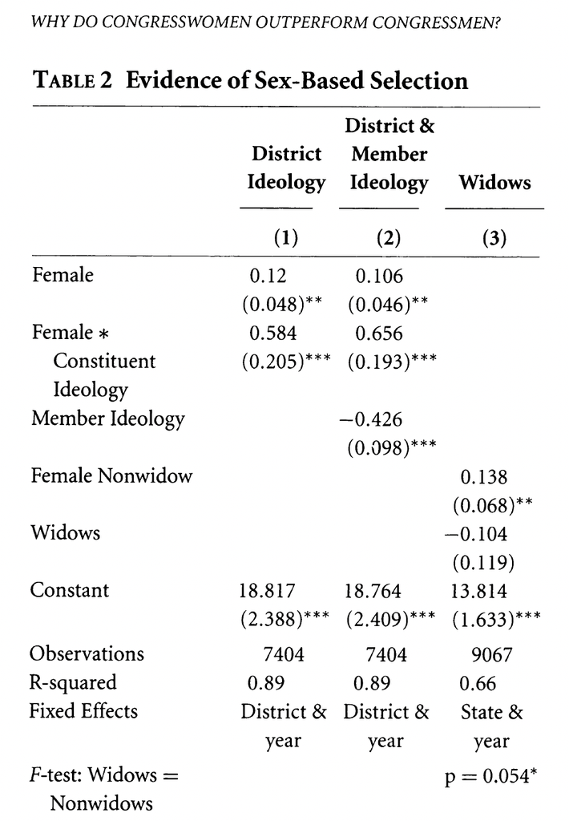

## What most applied social scientists “know” about other estimation techniques

- When the dependent variable is **binary** (i.e. only 0 or 1), you shouldn’t use OLS
- Instead you should use **logit** or **probit**
- Logit and probit coefficients are hard to understand

## What most applied social scientists “know” about statistical inference

- Statistical software gives you a **standard error** for each regression coefficient. A bigger standard error means we are more uncertain what that coefficient really is.
- The **null hypothesis** is usually the claim that there is no relationship. We do **hypothesis testing** to see if we can reject the null hypothesis.
- If the **p-value** on your coefficient is below .05, your coefficient is **statistically significant** and you can **reject the null hypothesis**. This means the coefficient probably isn’t zero because the relationship is unlikely to have occurred by chance. If you get a p-value above .05, you didn’t find anything and your analysis didn’t work.

## What we want you to know

You need to know the correct parts above! (e.g. reading regression table, interpreting interaction terms)

But also, we want you

- to avoid the misconceptions (the stuff in orange and red)
- to understand common approaches to uncertainty (e.g. standard errors) and hypothesis testing (e.g. p-values): the logic behind these approaches and their limits.
- to see what coin flips and urns have to do with social science.